# SmartStay Advisors – Predicción de Precios con K-Nearest Neighbors

## Normalización de variables (min-max)

KNN basa sus predicciones en distancias entre observaciones. Si las variables tienen escalas muy distintas (ej.: `accommodates` va de 1–16 pero `number_of_reviews` puede llegar a 600+), las variables de mayor magnitud dominarán el cálculo de distancia de forma artificial. Por eso **normalizar es un paso crítico y no opcional**.

Se aplica normalización Min-Max usando únicamente los parámetros del conjunto de entrenamiento, y luego esos mismos parámetros se aplican al conjunto de prueba para evitar *data leakage*.

```r
# Separar la variable respuesta
y_train <- train_raw$price
y_test  <- test_raw$price

# Features (todo excepto price)
X_train_raw <- train_raw %>% select(-price)
X_test_raw  <- test_raw  %>% select(-price)

# Calcular parámetros Min-Max SOLO sobre train
preproc_params <- preProcess(X_train_raw, method = c("range"))

# Aplicar la misma transformación a train y test
X_train_norm <- predict(preproc_params, X_train_raw)
X_test_norm  <- predict(preproc_params, X_test_raw)

# Verificar rango: todo debe estar entre 0 y 1
apply(X_train_norm, 2, range) %>%
  t() %>%
  as.data.frame() %>%
  setNames(c("Min", "Max")) %>%
  kable(caption = "Rango de variables normalizadas (train)") %>%
  kable_styling(bootstrap_options = c("striped", "hover"), full_width = FALSE)
```

Rango de variables normalizadas (train)

|  | Min | Max |
| --- | --- | --- |
| accommodates | 0 | 1 |
| bedrooms | 0 | 1 |
| bathrooms | 0 | 1 |
| beds | 0 | 1 |
| minimum_nights | 0 | 1 |
| number_of_reviews | 0 | 1 |
| review_scores_rating | 0 | 1 |
| calculated_host_listings_count | 0 | 1 |
| availability_365 | 0 | 1 |

## Cómo funciona KNN en regresión

KNN (K-Nearest Neighbors) es un algoritmo de aprendizaje supervisado no paramétrico. En su versión de **regresión**, para predecir el precio de una propiedad nueva:

1. Calcula la **distancia euclidiana** entre esa propiedad y todas las del conjunto de entrenamiento (usando las variables normalizadas).
2. Identifica los **K vecinos más cercanos** (las K propiedades más similares).
3. Calcula el **promedio del precio** de esos K vecinos como predicción.

El hiperparámetro **K** controla el balance entre sesgo y varianza: - K pequeño → modelo flexible, puede sobreajustarse - K grande → modelo suavizado, puede subajustarse

Para la selección inicial de K se utiliza la heurística `K ≈ √n` como punto de partida, y luego se valida con RMSE en entrenamiento.

```r
# Heurística: K inicial ≈ sqrt(n_train)
k_heuristica <- round(sqrt(nrow(X_train_norm)))
cat(sprintf("K heurístico (√%d): %d\n", nrow(X_train_norm), k_heuristica))
```

```
## K heurístico (√49204): 222
```

```r
# Si k es par, hacerlo impar para evitar empates (buena práctica)
if (k_heuristica %% 2 == 0) k_heuristica <- k_heuristica + 1
cat(sprintf("K ajustado (impar): %d\n", k_heuristica))
```

```
## K ajustado (impar): 223
```

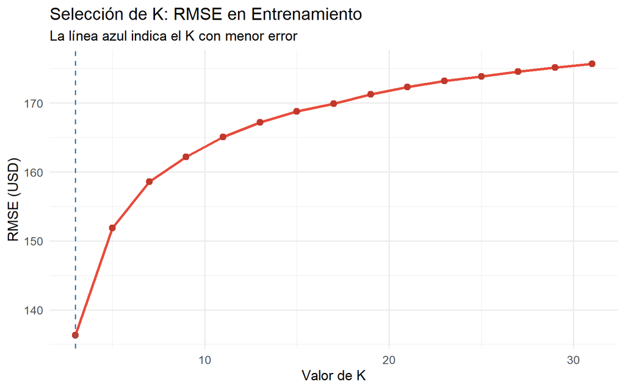

```r
# Probar varios valores de K y evaluar RMSE en train con CV simple
k_valores <- seq(3, 31, by = 2)  # solo impares
rmse_k    <- numeric(length(k_valores))

for (i in seq_along(k_valores)) {
  pred_train_cv <- knn.reg(
    train = X_train_norm,
    test  = X_train_norm,
    y     = y_train,
    k     = k_valores[i]
  )$pred

  rmse_k[i] <- rmse(y_train, pred_train_cv)
}

resultados_k <- data.frame(K = k_valores, RMSE_train = round(rmse_k, 4))

# Graficar curva de error
ggplot(resultados_k, aes(x = K, y = RMSE_train)) +
  geom_line(color = "#e74c3c", linewidth = 1.2) +
  geom_point(color = "#c0392b", size = 2.5) +
  geom_vline(
    xintercept = k_valores[which.min(rmse_k)],
    linetype = "dashed", color = "#2c7bb6"
  ) +
  labs(
    title = "Selección de K: RMSE en Entrenamiento",
    subtitle = "La línea azul indica el K con menor error",
    x = "Valor de K",
    y = "RMSE (USD)"
  ) +
  theme_minimal(base_size = 13)
```

```r
k_optimo <- k_valores[which.min(rmse_k)]
cat(sprintf("\nK óptimo seleccionado: %d (RMSE train = $%.2f)\n",
            k_optimo, min(rmse_k)))
```

```
##
## K óptimo seleccionado: 3 (RMSE train = $136.34)
```

## Entrenamiento del modelo KNN de regresión

```r
# Entrenar KNN con el K óptimo identificado
modelo_knn_reg <- knn.reg(
  train = X_train_norm,
  test  = X_train_norm,   # predicciones sobre train primero
  y     = y_train,
  k     = k_optimo
)

pred_train <- modelo_knn_reg$pred

# Métricas en entrenamiento (referencia interna)
rmse_train <- rmse(y_train, pred_train)
mae_train  <- mae(y_train,  pred_train)
r2_train   <- cor(y_train,  pred_train)^2

cat("--- Métricas en Entrenamiento (referencia) ---\n")
```

```
## --- Métricas en Entrenamiento (referencia) ---
```

```r
cat(sprintf("RMSE : $%.4f\n", rmse_train))
```

```
## RMSE : $136.3406
```

```r
cat(sprintf("MAE  : $%.4f\n", mae_train))
```

```
## MAE  : $78.4770
```

```r
cat(sprintf("R²   : %.4f\n",  r2_train))
```

```
## R²   : 0.7226
```

## Predicción sobre el conjunto de prueba

```r
# Predecir sobre test set (datos no vistos durante el entrenamiento)
pred_test_obj <- knn.reg(
  train = X_train_norm,
  test  = X_test_norm,
  y     = y_train,
  k     = k_optimo
)

pred_test <- pred_test_obj$pred

# Primeras predicciones vs valores reales
head(data.frame(
  Real     = round(y_test, 2),
  Predicho = round(pred_test, 2),
  Error    = round(y_test - pred_test, 2)
), 10) %>%
  kable(caption = "Primeras 10 predicciones vs valores reales (test set)") %>%
  kable_styling(bootstrap_options = c("striped", "hover"), full_width = FALSE)
```

Primeras 10 predicciones vs valores reales (test set)

| Real | Predicho | Error |
| --- | --- | --- |
| 300 | 235.00 | 65.00 |
| 103 | 177.67 | -74.67 |
| 167 | 283.33 | -116.33 |
| 168 | 209.67 | -41.67 |
| 550 | 334.67 | 215.33 |
| 139 | 174.33 | -35.33 |
| 358 | 551.00 | -193.00 |
| 426 | 404.67 | 21.33 |
| 68 | 150.00 | -82.00 |
| 102 | 144.67 | -42.67 |

## Evaluación del modelo en el conjunto de prueba

Esta sección responde directamente a la pregunta central: **¿qué tan bien predice el modelo KNN en datos que nunca vio durante el entrenamiento?**

```r
# Calcular métricas en TEST SET
rmse_test <- rmse(y_test, pred_test)
mae_test  <- mae(y_test,  pred_test)
r2_test   <- cor(y_test,  pred_test)^2

# Tabla resumen
metricas_df <- data.frame(
  Conjunto   = c("Entrenamiento", "Prueba (Test)"),
  RMSE       = round(c(rmse_train, rmse_test), 4),
  MAE        = round(c(mae_train,  mae_test),  4),
  R2         = round(c(r2_train,   r2_test),   4)
)

metricas_df %>%
  kable(
    col.names = c("Conjunto", "RMSE (USD)", "MAE (USD)", "R²"),
    caption   = "Desempeño del modelo KNN de regresión (K = óptimo)"
  ) %>%
  kable_styling(bootstrap_options = c("striped", "hover"), full_width = FALSE) %>%
  row_spec(2, bold = TRUE, background = "#eaf4fb")
```

Desempeño del modelo KNN de regresión (K = óptimo)

| Conjunto | RMSE (USD) | MAE (USD) | R² |
| --- | --- | --- | --- |
| Entrenamiento | 136.3406 | 78.4770 | 0.7226 |
| Prueba (Test) | 191.4262 | 110.9401 | 0.4643 |

### Interpretación de las métricas

- **RMSE (Root Mean Squared Error):** Penaliza errores grandes. Un RMSE de 191.43 USD indica que, en promedio, las predicciones se desvían 191.43 dólares del precio real en el conjunto de prueba.
- **MAE (Mean Absolute Error):** Error absoluto promedio de 110.94 USD. Más robusto a outliers que el RMSE.
- **R² (Coeficiente de determinación):** El modelo explica el 46.4% de la varianza del precio en datos no vistos. El ajuste es moderado, con margen de mejora.

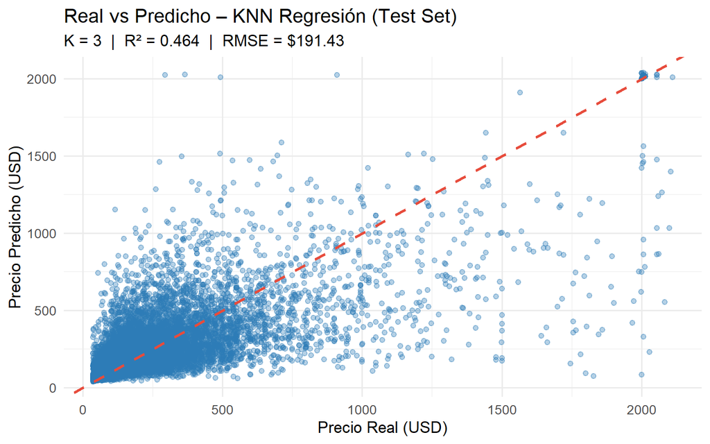

Valores reales vs predichos – KNN Regresión (test set)

```r
df_resultados <- data.frame(
  Real     = y_test,
  Predicho = pred_test
)

ggplot(df_resultados, aes(x = Real, y = Predicho)) +
  geom_point(alpha = 0.35, color = "#2c7bb6", size = 1.8) +
  geom_abline(slope = 1, intercept = 0,
              color = "#e74c3c", linetype = "dashed", linewidth = 1.1) +
  labs(
    title    = "Real vs Predicho – KNN Regresión (Test Set)",
    subtitle = sprintf("K = %d  |  R² = %.3f  |  RMSE = $%.2f", k_optimo, r2_test, rmse_test),
    x = "Precio Real (USD)",
    y = "Precio Predicho (USD)"
  ) +
  theme_minimal(base_size = 13)
```

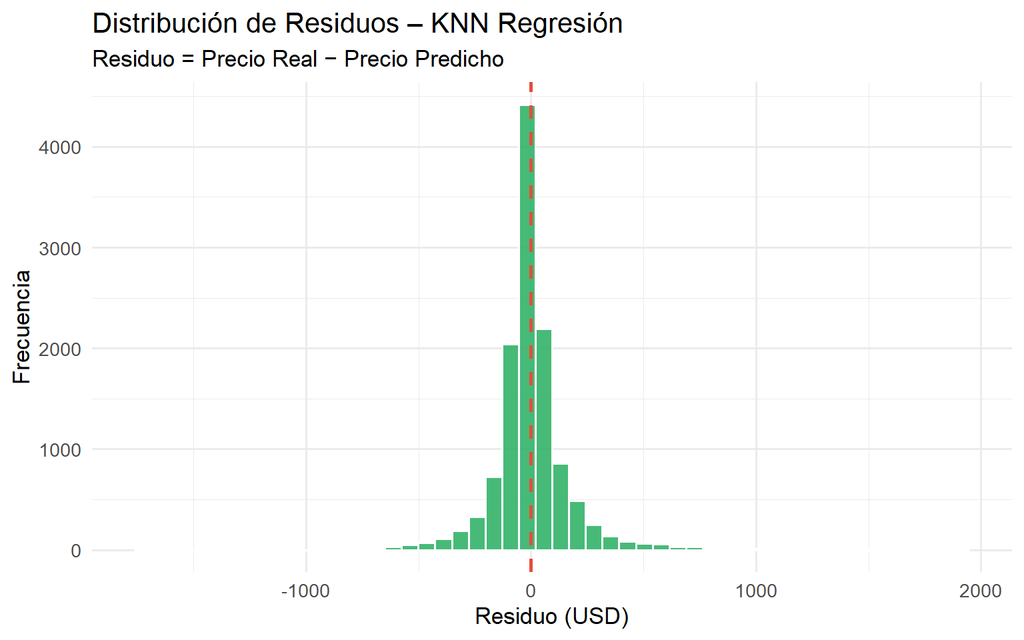

Distribución de residuos en el test set

```r
df_resultados <- df_resultados %>%
  mutate(Residuo = Real - Predicho)

ggplot(df_resultados, aes(x = Residuo)) +
  geom_histogram(bins = 50, fill = "#27ae60", color = "white", alpha = 0.85) +
  geom_vline(xintercept = 0, color = "#e74c3c", linetype = "dashed", linewidth = 1) +
  labs(
    title    = "Distribución de Residuos – KNN Regresión",
    subtitle = "Residuo = Precio Real − Precio Predicho",
    x = "Residuo (USD)",
    y = "Frecuencia"
  ) +
  theme_minimal(base_size = 13)
```

```r
cat(sprintf("Residuo promedio: $%.4f (sesgo del modelo)\n", mean(df_resultados$Residuo)))
```

```
## Residuo promedio: $1.4132 (sesgo del modelo)
```

```r
cat(sprintf("¿Sobreestima o subestima?\n%s\n",
    ifelse(mean(df_resultados$Residuo) > 0,
           "El modelo tiende a SUBESTIMAR los precios reales.",
           "El modelo tiende a SOBREESTIMAR los precios reales.")))
```

```
## ¿Sobreestima o subestima?
## El modelo tiende a SUBESTIMAR los precios reales.
```

## Decisiones metodológicas documentadas

```r
decisiones <- data.frame(
  Decisión       = c(
    "K seleccionado",
    "Método de normalización",
    "Split train/test",
    "Filtro de outliers",
    "Métrica de distancia",
    "Variables utilizadas"
  ),
  Valor          = c(
    as.character(k_optimo),
    "Min-Max (rango [0,1])",
    "80% train / 20% test (set.seed = 123)",
    "Percentiles 1%–99% del precio",
    "Euclidiana (default FNN)",
    paste(setdiff(vars_disponibles, "price"), collapse = ", ")
  ),
  Justificación  = c(
    "Mínimo RMSE en barrido K = {3,5,...,31}; ajustado a impar",
    "Obligatorio en KNN: evita dominancia por escala",
    "Idéntico a entregas anteriores para comparación válida",
    "Elimina precios no representativos del mercado típico",
    "Estándar para variables continuas normalizadas",
    "Variables numéricas relevantes del negocio; sin leakage"
  )
)

decisiones %>%
  kable(caption = "Registro de decisiones metodológicas") %>%
  kable_styling(bootstrap_options = c("striped", "hover"), full_width = TRUE) %>%
  column_spec(1, bold = TRUE, width = "18%") %>%
  column_spec(2, width = "28%") %>%
  column_spec(3, width = "54%")
```

Registro de decisiones metodológicas

| Decisión | Valor | Justificación |
| --- | --- | --- |
| K seleccionado | 3 | Mínimo RMSE en barrido K = {3,5,…,31}; ajustado a impar |
| Método de normalización | Min-Max (rango [0,1]) | Obligatorio en KNN: evita dominancia por escala |
| Split train/test | 80% train / 20% test (set.seed = 123) | Idéntico a entregas anteriores para comparación válida |
| Filtro de outliers | Percentiles 1%–99% del precio | Elimina precios no representativos del mercado típico |
| Métrica de distancia | Euclidiana (default FNN) | Estándar para variables continuas normalizadas |
| Variables utilizadas | accommodates, bedrooms, bathrooms, beds, minimum_nights, number_of_reviews, review_scores_rating, calculated_host_listings_count, availability_365 | Variables numéricas relevantes del negocio; sin leakage |

## Conclusiones parciales

El modelo KNN de regresión logró un **R² de 0.464** y un **RMSE de $191.43** en el conjunto de prueba, lo que indica una capacidad predictiva moderada para estimar precios de propiedades Airbnb a partir de sus características físicas y de disponibilidad.

La diferencia entre las métricas de entrenamiento y prueba sugiere cierta tendencia al sobreajuste que puede mitigarse aumentando K o reduciendo features. En entregas siguientes se complementará este análisis con validación cruzada y búsqueda de hiperparámetros más exhaustiva (Actividades 7–9).

```r
# Exportar objetos para reutilización en secciones posteriores
save(
  train_raw, test_raw,
  X_train_norm, X_test_norm,
  y_train, y_test,
  preproc_params,
  modelo_knn_reg, pred_test,
  k_optimo,
  rmse_test, mae_test, r2_test,
  file = "knn_regresion_resultados.RData"
)

cat("Objetos exportados a: knn_regresion_resultados.RData\n")
```

```
## Objetos exportados a: knn_regresion_resultados.RData
```

```r
cat("(Cargar este archivo para asegurar el mismo split en todo el análisis)\n")
```

```
## (Cargar este archivo para asegurar el mismo split en todo el análisis)
```

# Evaluación y Comparación de Modelos

## Preparación del entorno

```r
# Paquetes adicionales para los modelos de comparación
paquetes_b <- c("rpart", "rpart.plot", "e1071")
faltantes_b <- paquetes_b[!paquetes_b %in% installed.packages()[, "Package"]]
if (length(faltantes_b) > 0) install.packages(faltantes_b)

library(rpart)
library(rpart.plot)
library(e1071)
```

```r
# Cargar objetos generados en la sección previa
# Esto garantiza el mismo split train/test en todos los modelos
load("knn_regresion_resultados.RData")

cat("Objetos disponibles de la sección previa:\n")
```

```
## Objetos disponibles de la sección previa:
```

```r
cat(sprintf("  - Train: %d observaciones\n", nrow(train_raw)))
```

```
##   - Train: 49204 observaciones
```

```r
cat(sprintf("  - Test : %d observaciones\n", nrow(test_raw)))
```

```
##   - Test : 12298 observaciones
```

```r
cat(sprintf("  - KNN k óptimo: %d\n", k_optimo))
```

```
##   - KNN k óptimo: 3
```

```r
cat(sprintf("  - KNN RMSE test: $%.4f\n", rmse_test))
```

```
##   - KNN RMSE test: $191.4262
```

## Evaluación detallada del modelo KNN de regresión

Antes de comparar contra otros modelos, se profundiza en el comportamiento del KNN: cómo distribuye sus errores y si existe sesgo sistemático de sobreestimación o subestimación.

```r
# Reconstruir data frame de resultados KNN
df_knn <- data.frame(
  Real     = y_test,
  Predicho = pred_test,
  Residuo  = y_test - pred_test
)

residuo_medio <- mean(df_knn$Residuo)
pct_sobreestima <- mean(df_knn$Residuo < 0) * 100
pct_subestima   <- mean(df_knn$Residuo > 0) * 100

cat("--- Análisis de Sesgo del KNN ---\n")
```

```
## --- Análisis de Sesgo del KNN ---
```

```r
cat(sprintf("Residuo medio        : $%.4f\n", residuo_medio))
```

```
## Residuo medio        : $1.4132
```

```r
cat(sprintf("Predicciones donde subestima (Real > Predicho): %.1f%%\n", pct_subestima))
```

```
## Predicciones donde subestima (Real > Predicho): 44.0%
```

```r
cat(sprintf("Predicciones donde sobreestima (Real < Predicho): %.1f%%\n", pct_sobreestima))
```

```
## Predicciones donde sobreestima (Real < Predicho): 55.3%
```

```r
cat(sprintf("\nConclusión: %s\n",
    ifelse(residuo_medio > 5,
           "El modelo tiende a SUBESTIMAR los precios reales.",
           ifelse(residuo_medio < -5,
                  "El modelo tiende a SOBREESTIMAR los precios reales.",
                  "El modelo no presenta sesgo sistemático relevante."))))
```

```
##
## Conclusión: El modelo no presenta sesgo sistemático relevante.
```

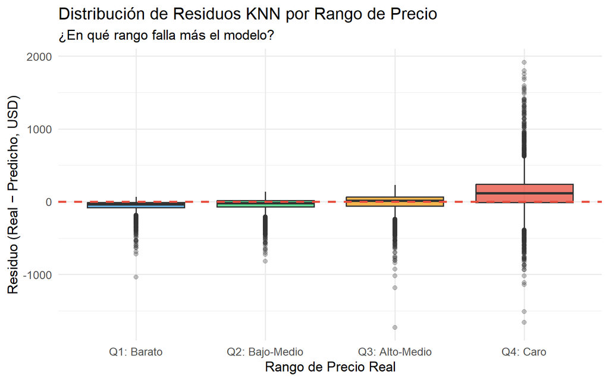

Residuos del KNN según rango de precio real

```r
# Clasificar observaciones en cuartiles de precio para ver dónde falla más
df_knn <- df_knn %>%
  mutate(
    Rango_precio = cut(
      Real,
      breaks = quantile(Real, probs = c(0, 0.25, 0.50, 0.75, 1.0)),
      labels = c("Q1: Barato", "Q2: Bajo-Medio", "Q3: Alto-Medio", "Q4: Caro"),
      include.lowest = TRUE
    )
  )

ggplot(df_knn, aes(x = Rango_precio, y = Residuo, fill = Rango_precio)) +
  geom_boxplot(alpha = 0.75, outlier.alpha = 0.3) +
  geom_hline(yintercept = 0, color = "#e74c3c", linetype = "dashed", linewidth = 1) +
  scale_fill_manual(values = c("#3498db", "#2ecc71", "#f39c12", "#e74c3c")) +
  labs(
    title    = "Distribución de Residuos KNN por Rango de Precio",
    subtitle = "¿En qué rango falla más el modelo?",
    x = "Rango de Precio Real",
    y = "Residuo (Real − Predicho, USD)"
  ) +
  theme_minimal(base_size = 13) +
  theme(legend.position = "none")
```

```r
# Resumen de RMSE por cuartil de precio
resumen_rangos <- df_knn %>%
  group_by(Rango_precio) %>%
  summarise(
    N       = n(),
    RMSE    = round(sqrt(mean(Residuo^2)), 2),
    MAE     = round(mean(abs(Residuo)), 2),
    Sesgo   = round(mean(Residuo), 2),
    .groups = "drop"
  )

resumen_rangos %>%
  kable(
    col.names = c("Rango de Precio", "N", "RMSE (USD)", "MAE (USD)", "Sesgo Medio (USD)"),
    caption   = "Desempeño del KNN por cuartil de precio real (test set)"
  ) %>%
  kable_styling(bootstrap_options = c("striped", "hover"), full_width = FALSE) %>%
  column_spec(3, bold = TRUE)
```

Desempeño del KNN por cuartil de precio real (test set)

| Rango de Precio | N | RMSE (USD) | MAE (USD) | Sesgo Medio (USD) |
| --- | --- | --- | --- | --- |
| Q1: Barato | 3076 | 95.60 | 61.49 | -57.06 |
| Q2: Bajo-Medio | 3094 | 107.78 | 67.29 | -45.16 |
| Q3: Alto-Medio | 3082 | 135.56 | 87.51 | -17.81 |
| Q4: Caro | 3046 | 329.13 | 228.92 | 127.22 |

## Modelos de comparación

Para una comparación justa, todos los modelos se entrenan con `train_raw` y se evalúan sobre `test_raw`, usando exactamente el mismo split base.

### Regresión Lineal

```r
# Entrenar regresión lineal con todas las variables del modelo
modelo_lm <- lm(price ~ ., data = train_raw)

# Predecir en test set
pred_lm <- predict(modelo_lm, newdata = test_raw)

# Métricas
rmse_lm <- rmse(y_test, pred_lm)
mae_lm  <- mae(y_test,  pred_lm)
r2_lm   <- cor(y_test,  pred_lm)^2

cat("--- Regresión Lineal (Test Set) ---\n")
```

```
## --- Regresión Lineal (Test Set) ---
```

```r
cat(sprintf("RMSE : $%.4f\n", rmse_lm))
```

```
## RMSE : $203.4499
```

```r
cat(sprintf("MAE  : $%.4f\n", mae_lm))
```

```
## MAE  : $120.2305
```

```r
cat(sprintf("R²   : %.4f\n",  r2_lm))
```

```
## R²   : 0.3672
```

### Árbol de Regresión

```r
# Entrenar árbol de regresión (ANOVA = modo regresión en rpart)
modelo_arbol <- rpart(
  price ~ .,
  data    = train_raw,
  method  = "anova",
  control = rpart.control(cp = 0.01, minsplit = 20)
)

# Predecir en test set
pred_arbol <- predict(modelo_arbol, newdata = test_raw)

# Métricas
rmse_arbol <- rmse(y_test, pred_arbol)
mae_arbol  <- mae(y_test,  pred_arbol)
r2_arbol   <- cor(y_test,  pred_arbol)^2

cat("--- Árbol de Regresión (Test Set) ---\n")
```

```
## --- Árbol de Regresión (Test Set) ---
```

```r
cat(sprintf("RMSE : $%.4f\n", rmse_arbol))
```

```
## RMSE : $190.8001
```

```r
cat(sprintf("MAE  : $%.4f\n", mae_arbol))
```

```
## MAE  : $117.7433
```

```r
cat(sprintf("R²   : %.4f\n",  r2_arbol))
```

```
## R²   : 0.4435
```

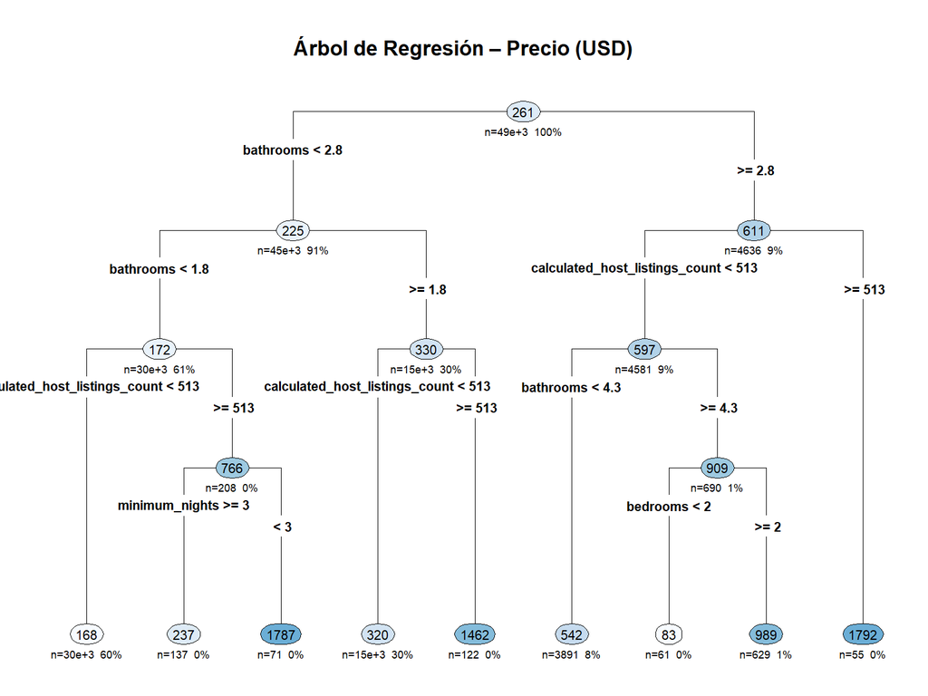

Estructura del árbol de regresión (cp = 0.01)

```r
rpart.plot(
  modelo_arbol,
  type    = 4,
  extra   = 101,
  under   = TRUE,
  cex     = 0.7,
  main    = "Árbol de Regresión – Precio (USD)"
)
```

### Naive Bayes (aproximación a regresión)

Naive Bayes es un clasificador, no un modelo de regresión directa. Para incluirlo en la comparación se discretiza el precio en tres categorías (terciles: **barata / media / cara**), se entrena el clasificador y las predicciones de categoría se mapean al precio mediano observado en entrenamiento para cada grupo. Esto permite calcular RMSE/MAE comparables.

```r
# Definir terciles sobre el set de entrenamiento
q33 <- quantile(train_raw$price, 1/3)
q67 <- quantile(train_raw$price, 2/3)

# Medianas de cada grupo (para convertir predicciones categoriales a numéricas)
med_barata <- median(train_raw$price[train_raw$price <= q33])
med_media  <- median(train_raw$price[train_raw$price > q33 & train_raw$price <= q67])
med_cara   <- median(train_raw$price[train_raw$price > q67])

cat(sprintf("Terciles (train) – Barata: ≤$%.0f | Media: $%.0f–$%.0f | Cara: >$%.0f\n",
            q33, q33, q67, q67))
```

```
## Terciles (train) – Barata: ≤$137 | Media: $137–$249 | Cara: >$249
```

```r
cat(sprintf("Mediana por grupo – Barata: $%.2f | Media: $%.2f | Cara: $%.2f\n",
            med_barata, med_media, med_cara))
```

```
## Mediana por grupo – Barata: $99.00 | Media: $183.00 | Cara: $382.00
```

```r
# Preparar datasets con variable categórica
train_nb <- train_raw %>%
  mutate(price_cat = cut(
    price,
    breaks = c(-Inf, q33, q67, Inf),
    labels = c("barata", "media", "cara")
  )) %>%
  select(-price)

test_nb <- test_raw %>% select(-price)

# Entrenar Naive Bayes
modelo_nb <- naiveBayes(price_cat ~ ., data = train_nb)

# Predecir categoría en test set
pred_nb_cat <- predict(modelo_nb, newdata = test_nb)

# Convertir categoría → valor numérico (mediana del grupo)
pred_nb_num <- dplyr::case_when(
  pred_nb_cat == "barata" ~ med_barata,
  pred_nb_cat == "media"  ~ med_media,
  pred_nb_cat == "cara"   ~ med_cara
)

# Métricas
rmse_nb <- rmse(y_test, pred_nb_num)
mae_nb  <- mae(y_test,  pred_nb_num)
r2_nb   <- cor(y_test,  pred_nb_num)^2

cat("\n--- Naive Bayes → Regresión aproximada (Test Set) ---\n")
```

```
##
## --- Naive Bayes → Regresión aproximada (Test Set) ---
```

```r
cat(sprintf("RMSE : $%.4f\n", rmse_nb))
```

```
## RMSE : $234.0556
```

```r
cat(sprintf("MAE  : $%.4f\n", mae_nb))
```

```
## MAE  : $124.8938
```

```r
cat(sprintf("R²   : %.4f\n",  r2_nb))
```

```
## R²   : 0.2379
```

```r
# Distribución de predicciones categóricas
cat("\nDistribución de predicciones NB:\n")
```

```
##
## Distribución de predicciones NB:
```

```r
print(table(pred_nb_cat))
```

```
## pred_nb_cat
## barata  media   cara
##   6300   2949   3049
```

## Tabla comparativa de modelos

```r
comparacion <- data.frame(
  Modelo = c("KNN Regresión", "Regresión Lineal", "Árbol de Regresión", "Naive Bayes*"),
  RMSE   = round(c(rmse_test, rmse_lm, rmse_arbol, rmse_nb), 2),
  MAE    = round(c(mae_test,  mae_lm,  mae_arbol,  mae_nb),  2),
  R2     = round(c(r2_test,   r2_lm,   r2_arbol,   r2_nb),   4)
)

# Identificar mejor modelo por RMSE
mejor_idx <- which.min(comparacion$RMSE)

comparacion %>%
  kable(
    col.names = c("Modelo", "RMSE (USD)", "MAE (USD)", "R²"),
    caption   = "Comparación de modelos de predicción de precio (test set) | *NB aproximado vía medianas de terciles"
  ) %>%
  kable_styling(bootstrap_options = c("striped", "hover"), full_width = FALSE) %>%
  row_spec(mejor_idx, bold = TRUE, background = "#d5f5e3") %>%
  row_spec(0, bold = TRUE)
```

Comparación de modelos de predicción de precio (test set) | *NB aproximado vía medianas de terciles

| Modelo | RMSE (USD) | MAE (USD) | R² |
| --- | --- | --- | --- |
| KNN Regresión | 191.43 | 110.94 | 0.4643 |
| Regresión Lineal | 203.45 | 120.23 | 0.3672 |
| Árbol de Regresión | 190.80 | 117.74 | 0.4435 |
| Naive Bayes* | 234.06 | 124.89 | 0.2379 |

## Visualizaciones comparativas

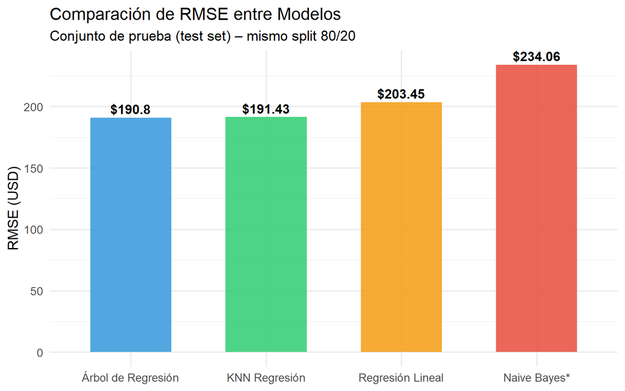

RMSE por modelo – menor es mejor

```r
comparacion_long <- comparacion %>%
  mutate(Modelo = factor(Modelo, levels = Modelo[order(RMSE)]))

ggplot(comparacion_long, aes(x = Modelo, y = RMSE, fill = Modelo)) +
  geom_col(alpha = 0.85, width = 0.6) +
  geom_text(aes(label = paste0("$", RMSE)), vjust = -0.4, size = 4.2, fontface = "bold") +
  scale_fill_manual(values = c("#3498db", "#2ecc71", "#f39c12", "#e74c3c")) +
  labs(
    title    = "Comparación de RMSE entre Modelos",
    subtitle = "Conjunto de prueba (test set) – mismo split 80/20",
    x = NULL,
    y = "RMSE (USD)"
  ) +
  theme_minimal(base_size = 13) +
  theme(legend.position = "none")
```

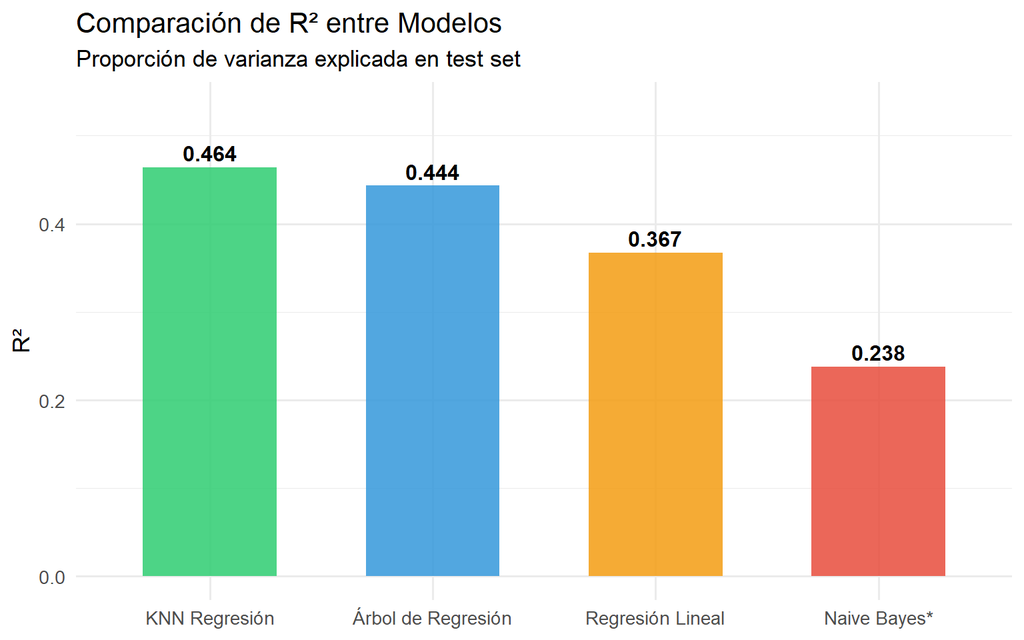

R² por modelo – mayor es mejor

```r
comparacion_r2 <- comparacion %>%
  mutate(Modelo = factor(Modelo, levels = Modelo[order(-R2)]))

ggplot(comparacion_r2, aes(x = Modelo, y = R2, fill = Modelo)) +
  geom_col(alpha = 0.85, width = 0.6) +
  geom_text(aes(label = round(R2, 3)), vjust = -0.4, size = 4.2, fontface = "bold") +
  scale_fill_manual(values = c("#2ecc71", "#3498db", "#f39c12", "#e74c3c")) +
  scale_y_continuous(limits = c(0, max(comparacion$R2) * 1.15)) +
  labs(
    title    = "Comparación de R² entre Modelos",
    subtitle = "Proporción de varianza explicada en test set",
    x = NULL,
    y = "R²"
  ) +
  theme_minimal(base_size = 13) +
  theme(legend.position = "none")
```

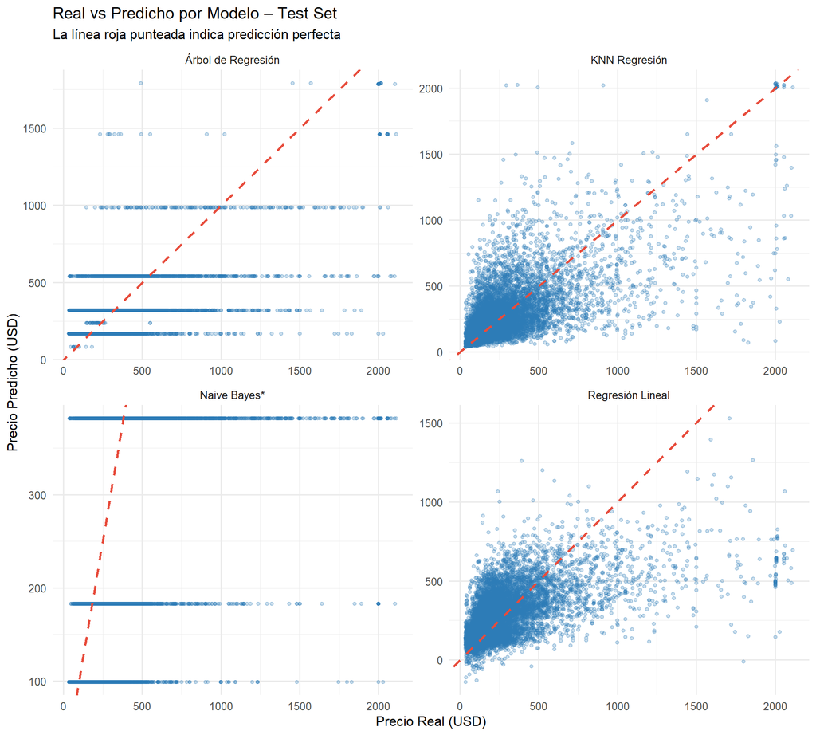

Real vs Predicho para cada modelo (test set)

```r
# Unir todas las predicciones en un solo data frame largo
df_comp <- bind_rows(
  data.frame(Real = y_test, Predicho = pred_test,  Modelo = "KNN Regresión"),
  data.frame(Real = y_test, Predicho = pred_lm,    Modelo = "Regresión Lineal"),
  data.frame(Real = y_test, Predicho = pred_arbol, Modelo = "Árbol de Regresión"),
  data.frame(Real = y_test, Predicho = pred_nb_num, Modelo = "Naive Bayes*")
)

ggplot(df_comp, aes(x = Real, y = Predicho)) +
  geom_point(alpha = 0.25, color = "#2c7bb6", size = 1.2) +
  geom_abline(slope = 1, intercept = 0, color = "#e74c3c",
              linetype = "dashed", linewidth = 0.9) +
  facet_wrap(~ Modelo, scales = "free", ncol = 2) +
  labs(
    title    = "Real vs Predicho por Modelo – Test Set",
    subtitle = "La línea roja punteada indica predicción perfecta",
    x = "Precio Real (USD)",
    y = "Precio Predicho (USD)"
  ) +
  theme_minimal(base_size = 12)
```

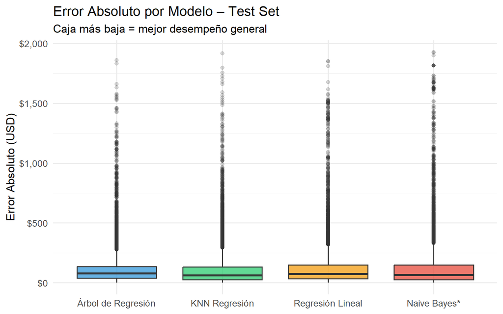

Distribución de residuos absolutos por modelo

```r
df_comp <- df_comp %>%
  mutate(
    Residuo_abs = abs(Real - Predicho),
    Modelo      = factor(Modelo, levels = comparacion$Modelo[order(comparacion$RMSE)])
  )

ggplot(df_comp, aes(x = Modelo, y = Residuo_abs, fill = Modelo)) +
  geom_boxplot(alpha = 0.75, outlier.alpha = 0.2) +
  scale_fill_manual(values = c("#3498db", "#2ecc71", "#f39c12", "#e74c3c")) +
  scale_y_continuous(labels = scales::dollar_format()) +
  labs(
    title    = "Error Absoluto por Modelo – Test Set",
    subtitle = "Caja más baja = mejor desempeño general",
    x = NULL,
    y = "Error Absoluto (USD)"
  ) +
  theme_minimal(base_size = 13) +
  theme(legend.position = "none")
```

## Análisis y conclusión

```r
mejor_modelo <- comparacion$Modelo[which.min(comparacion$RMSE)]
peor_modelo  <- comparacion$Modelo[which.max(comparacion$RMSE)]

cat("=== Resumen Ejecutivo ===\n\n")
```

```
## === Resumen Ejecutivo ===
```

```r
cat(sprintf("Mejor modelo por RMSE  : %s ($%.2f)\n", mejor_modelo, min(comparacion$RMSE)))
```

```
## Mejor modelo por RMSE  : Árbol de Regresión ($190.80)
```

```r
cat(sprintf("Mejor modelo por R²    : %s (%.4f)\n",
            comparacion$Modelo[which.max(comparacion$R2)], max(comparacion$R2)))
```

```
## Mejor modelo por R²    : KNN Regresión (0.4643)
```

```r
cat(sprintf("Modelo con mayor error : %s ($%.2f RMSE)\n\n", peor_modelo, max(comparacion$RMSE)))
```

```
## Modelo con mayor error : Naive Bayes* ($234.06 RMSE)
```

```r
# Diferencia KNN vs Regresión Lineal
diff_knn_lm <- rmse_test - rmse_lm
cat(sprintf("KNN vs Regresión Lineal (RMSE): %+.2f USD (%s)\n",
            diff_knn_lm,
            ifelse(diff_knn_lm < 0, "KNN es mejor", "Regresión Lineal es mejor")))
```

```
## KNN vs Regresión Lineal (RMSE): -12.02 USD (KNN es mejor)
```

```r
diff_knn_arbol <- rmse_test - rmse_arbol
cat(sprintf("KNN vs Árbol de Regresión (RMSE): %+.2f USD (%s)\n",
            diff_knn_arbol,
            ifelse(diff_knn_arbol < 0, "KNN es mejor", "Árbol es mejor")))
```

```
## KNN vs Árbol de Regresión (RMSE): +0.63 USD (Árbol es mejor)
```

### Interpretación final

```r
# Exportar para uso en integración final
save(
  comparacion,
  modelo_lm, pred_lm, rmse_lm, mae_lm, r2_lm,
  modelo_arbol, pred_arbol, rmse_arbol, mae_arbol, r2_arbol,
  modelo_nb, pred_nb_num, rmse_nb, mae_nb, r2_nb,
  q33, q67, med_barata, med_media, med_cara,
  file = "knn_comparacion_resultados.RData"
)

cat("Objetos exportados a: knn_comparacion_resultados.RData\n")
```

```
## Objetos exportados a: knn_comparacion_resultados.RData
```

```r
cat("(Este archivo puede cargarse para la integración final)\n")
```

```
## (Este archivo puede cargarse para la integración final)
```

# KNN Clasificación + Evaluación

## Preparación del entorno

```r
# Paquetes para clasificación y métricas
paquetes_c <- c("class")
faltantes_c <- paquetes_c[!paquetes_c %in% installed.packages()[, "Package"]]
if (length(faltantes_c) > 0) install.packages(faltantes_c)

library(class)

# Cargar split y objetos base del análisis
load("knn_regresion_resultados.RData")

cat("Split cargado correctamente para clasificación:\n")
```

```
## Split cargado correctamente para clasificación:
```

```r
cat(sprintf("  - Train: %d observaciones\n", nrow(train_raw)))
```

```
##   - Train: 49204 observaciones
```

```r
cat(sprintf("  - Test : %d observaciones\n", nrow(test_raw)))
```

```
##   - Test : 12298 observaciones
```

## 1) Variable categórica de precio (barata, media, cara)

Para evitar fuga de información, los puntos de corte se calculan **solo** con el conjunto de entrenamiento usando terciles. Luego se aplican esos mismos cortes al conjunto de prueba.

```r
# Definir terciles en TRAIN (criterio solicitado)
q33_c <- quantile(train_raw$price, probs = 1/3, na.rm = TRUE)
q67_c <- quantile(train_raw$price, probs = 2/3, na.rm = TRUE)

# Crear variable categórica en train y test con los mismos umbrales
train_cls <- train_raw %>%
  mutate(
    price_cat = cut(
      price,
      breaks = c(-Inf, q33_c, q67_c, Inf),
      labels = c("barata", "media", "cara"),
      include.lowest = TRUE,
      right = TRUE
    )
  )

test_cls <- test_raw %>%
  mutate(
    price_cat = cut(
      price,
      breaks = c(-Inf, q33_c, q67_c, Inf),
      labels = c("barata", "media", "cara"),
      include.lowest = TRUE,
      right = TRUE
    )
  )

cat("Criterio de categorización (terciles en train):\n")
```

```
## Criterio de categorización (terciles en train):
```

```r
cat(sprintf("  - barata: price <= $%.2f\n", q33_c))
```

```
##   - barata: price <= $137.00
```

```r
cat(sprintf("  - media : $%.2f < price <= $%.2f\n", q33_c, q67_c))
```

```
##   - media : $137.00 < price <= $249.00
```

```r
cat(sprintf("  - cara  : price > $%.2f\n", q67_c))
```

```
##   - cara  : price > $249.00
```

```r
# Verificar balance de clases
dist_train <- prop.table(table(train_cls$price_cat))
dist_test  <- prop.table(table(test_cls$price_cat))

balance_df <- data.frame(
  Clase = rep(c("barata", "media", "cara"), 2),
  Conjunto = rep(c("Train", "Test"), each = 3),
  Proporcion = c(as.numeric(dist_train), as.numeric(dist_test))
)

balance_df %>%
  mutate(Proporcion = round(Proporcion * 100, 2)) %>%
  kable(
    col.names = c("Clase", "Conjunto", "Proporción (%)"),
    caption = "Distribución de clases por conjunto"
  ) %>%
  kable_styling(bootstrap_options = c("striped", "hover"), full_width = FALSE)
```

Distribución de clases por conjunto

| Clase | Conjunto | Proporción (%) |
| --- | --- | --- |
| barata | Train | 33.37 |
| media | Train | 33.31 |
| cara | Train | 33.32 |
| barata | Test | 33.46 |
| media | Test | 33.21 |
| cara | Test | 33.33 |

## 2) Implementación de KNN clasificación

Se reutilizan las variables normalizadas (`X_train_norm`, `X_test_norm`) para mantener consistencia y comparabilidad.

```r
# Etiquetas objetivo
y_train_cls <- train_cls$price_cat
y_test_cls  <- test_cls$price_cat

# Búsqueda simple de K óptimo con accuracy sobre train
k_grid_cls <- seq(3, 31, by = 2)
acc_train_k <- numeric(length(k_grid_cls))

for (i in seq_along(k_grid_cls)) {
  pred_train_cls <- knn(
    train = X_train_norm,
    test = X_train_norm,
    cl = y_train_cls,
    k = k_grid_cls[i]
  )
  acc_train_k[i] <- mean(pred_train_cls == y_train_cls)
}

res_k_cls <- data.frame(K = k_grid_cls, Accuracy_train = acc_train_k)
k_opt_cls <- res_k_cls$K[which.max(res_k_cls$Accuracy_train)]

cat(sprintf("K óptimo para clasificación (según accuracy train): %d\n", k_opt_cls))
```

```
## K óptimo para clasificación (según accuracy train): 3
```

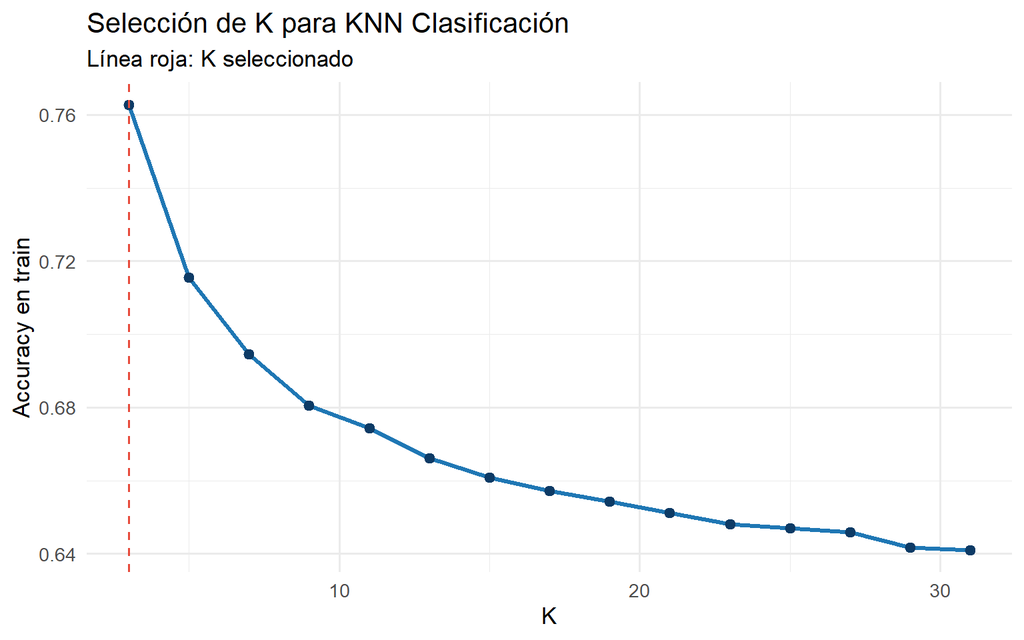

Accuracy en train según K (clasificación)

```r
ggplot(res_k_cls, aes(x = K, y = Accuracy_train)) +
  geom_line(color = "#1f77b4", linewidth = 1.1) +
  geom_point(color = "#0d3b66", size = 2.3) +
  geom_vline(xintercept = k_opt_cls, linetype = "dashed", color = "#e74c3c") +
  labs(
    title = "Selección de K para KNN Clasificación",
    subtitle = "Línea roja: K seleccionado",
    x = "K",
    y = "Accuracy en train"
  ) +
  theme_minimal(base_size = 13)
```

## 3) Predicción sobre test set

```r
pred_test_cls <- knn(
  train = X_train_norm,
  test  = X_test_norm,
  cl    = y_train_cls,
  k     = k_opt_cls
)

head(data.frame(
  Real = y_test_cls,
  Predicho = pred_test_cls
), 10) %>%
  kable(caption = "Primeras 10 predicciones de clasificación (test)") %>%
  kable_styling(bootstrap_options = c("striped", "hover"), full_width = FALSE)
```

Primeras 10 predicciones de clasificación (test)

| Real | Predicho |
| --- | --- |
| cara | media |
| barata | media |
| media | media |
| media | barata |
| cara | cara |
| media | media |
| cara | cara |
| cara | cara |
| barata | barata |
| barata | barata |

## 4) Evaluación del modelo (Accuracy, Precision, Recall)

```r
cm <- confusionMatrix(
  data = pred_test_cls,
  reference = y_test_cls
)

accuracy_cls <- as.numeric(cm$overall["Accuracy"])

# Métricas por clase: precision y recall
metricas_por_clase <- as.data.frame(cm$byClass)
metricas_por_clase$Clase <- rownames(metricas_por_clase)

metricas_resumen <- metricas_por_clase %>%
  transmute(
    Clase,
    Precision = round(`Pos Pred Value`, 4),
    Recall = round(Sensitivity, 4),
    F1 = round((2 * Precision * Recall) / pmax(Precision + Recall, .Machine$double.eps), 4)
  )

cat(sprintf("Accuracy en test: %.4f\n", accuracy_cls))
```

```
## Accuracy en test: 0.5830
```

```r
metricas_resumen %>%
  kable(caption = "Precision, Recall y F1 por clase (test)") %>%
  kable_styling(bootstrap_options = c("striped", "hover"), full_width = FALSE)
```

Precision, Recall y F1 por clase (test)

|  | Clase | Precision | Recall | F1 |
| --- | --- | --- | --- | --- |
| Class: barata | Class: barata | 0.6238 | 0.6508 | 0.6370 |
| Class: media | Class: media | 0.4769 | 0.4552 | 0.4658 |
| Class: cara | Class: cara | 0.6411 | 0.6424 | 0.6417 |

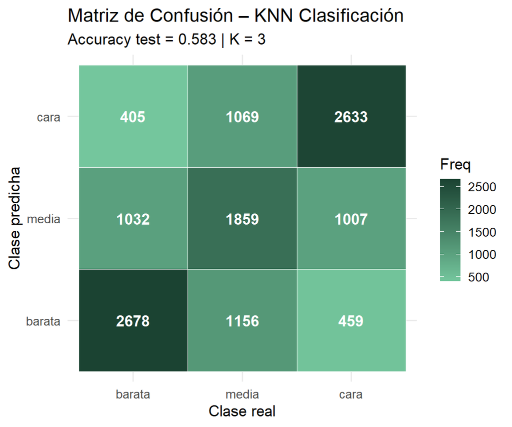

Matriz de confusión KNN clasificación (test)

```r
cm_df <- as.data.frame(cm$table)

ggplot(cm_df, aes(x = Reference, y = Prediction, fill = Freq)) +
  geom_tile(color = "white") +
  geom_text(aes(label = Freq), color = "white", fontface = "bold", size = 4.5) +
  scale_fill_gradient(low = "#74c69d", high = "#1b4332") +
  labs(
    title = "Matriz de Confusión – KNN Clasificación",
    subtitle = sprintf("Accuracy test = %.3f | K = %d", accuracy_cls, k_opt_cls),
    x = "Clase real",
    y = "Clase predicha"
  ) +
  theme_minimal(base_size = 13)
```

## 5) Análisis de resultados

```r
# Errores por clase real (usar columnas, porque Reference = clase real)
errores_por_clase <- data.frame(
  Clase_real = colnames(cm$table),
  Total = colSums(cm$table),
  Aciertos = diag(cm$table),
  Errores = colSums(cm$table) - diag(cm$table)
) %>%
  mutate(
    Error_pct = round(100 * Errores / pmax(Total, 1), 2)
  )

errores_por_clase %>%
  kable(
    col.names = c("Clase real", "Total", "Aciertos", "Errores", "Error (%)"),
    caption = "¿Donde falla mas el modelo?"
  ) %>%
  kable_styling(bootstrap_options = c("striped", "hover"), full_width = FALSE)
```

¿Donde falla mas el modelo?

|  | Clase real | Total | Aciertos | Errores | Error (%) |
| --- | --- | --- | --- | --- | --- |
| barata | barata | 4115 | 2678 | 1437 | 34.92 |
| media | media | 4084 | 1859 | 2225 | 54.48 |
| cara | cara | 4099 | 2633 | 1466 | 35.76 |

```r
clase_mas_dificil <- errores_por_clase$Clase_real[which.max(errores_por_clase$Error_pct)]
error_max <- max(errores_por_clase$Error_pct)

cat(sprintf("\nClase con mayor tasa de error: %s (%.2f%%)\n", clase_mas_dificil, error_max))
```

```
##
## Clase con mayor tasa de error: media (54.48%)
```

```r
# Diagnostico simple de desbalance
props_train <- prop.table(table(y_train_cls))
ratio_max_min <- max(props_train) / min(props_train)

cat(sprintf("Ratio clase mayoritaria/minoritaria en train: %.2f\n", ratio_max_min))
```

```
## Ratio clase mayoritaria/minoritaria en train: 1.00
```

```r
cat(sprintf("Diagnostico de balance: %s\n",
            ifelse(ratio_max_min > 1.5,
                   "Hay desbalance moderado/alto de clases.",
                   "No se observa desbalance fuerte de clases.")))
```

```
## Diagnostico de balance: No se observa desbalance fuerte de clases.
```

### Interpretacion inicial

- El modelo KNN de clasificacion alcanza un **accuracy de 0.583** en el conjunto de prueba.
- La clase con mayor dificultad de prediccion es **media**, donde se concentra la mayor tasa de error.
- El desempeño por clase (precision/recall) sugiere que el modelo no es homogeneo entre clases y necesita ajuste de K o variables.
- Sobre desbalance: las clases estan razonablemente balanceadas, con impacto limitado en el clasificador.

## Eficiencia multiclase y generalizacion

```r
# Prediccion en train con el K final (estimacion optimista al incluir autovecino)
pred_train_cls <- knn(
  train = X_train_norm,
  test  = X_train_norm,
  cl    = y_train_cls,
  k     = k_opt_cls
)

cm_train_cls <- confusionMatrix(pred_train_cls, y_train_cls)
cm_test_cls  <- cm

# Funcion para obtener metricas por clase + promedios macro y weighted
metricas_multiclase <- function(cm_obj) {
  byc <- as.data.frame(cm_obj$byClass)
  byc$Clase <- sub("^Class: ", "", rownames(byc))

  byc <- byc %>%
    transmute(
      Clase,
      Precision = `Pos Pred Value`,
      Recall = Sensitivity,
      F1 = ifelse(
        (`Pos Pred Value` + Sensitivity) == 0,
        NA_real_,
        2 * (`Pos Pred Value` * Sensitivity) / (`Pos Pred Value` + Sensitivity)
      ),
      Balanced_Acc_ovo = `Balanced Accuracy`
    )

  tabla <- as.matrix(cm_obj$table)
  soporte <- colSums(tabla)
  byc$Soporte <- as.numeric(soporte[byc$Clase])

  macro <- byc %>%
    summarise(
      Clase = "Macro avg",
      Precision = mean(Precision, na.rm = TRUE),
      Recall = mean(Recall, na.rm = TRUE),
      F1 = mean(F1, na.rm = TRUE),
      Balanced_Acc_ovo = mean(Balanced_Acc_ovo, na.rm = TRUE),
      Soporte = sum(Soporte)
    )

  weighted <- byc %>%
    summarise(
      Clase = "Weighted avg",
      Precision = weighted.mean(Precision, Soporte, na.rm = TRUE),
      Recall = weighted.mean(Recall, Soporte, na.rm = TRUE),
      F1 = weighted.mean(F1, Soporte, na.rm = TRUE),
      Balanced_Acc_ovo = weighted.mean(Balanced_Acc_ovo, Soporte, na.rm = TRUE),
      Soporte = sum(Soporte)
    )

  bind_rows(byc, macro, weighted)
}

metricas_clase_train <- metricas_multiclase(cm_train_cls)
metricas_clase_test  <- metricas_multiclase(cm_test_cls)

metricas_globales_train_test <- bind_rows(
  tibble(
    Conjunto = "Train",
    Accuracy = as.numeric(cm_train_cls$overall["Accuracy"]),
    Kappa = as.numeric(cm_train_cls$overall["Kappa"]),
    Balanced_Accuracy = metricas_clase_train$Recall[metricas_clase_train$Clase == "Macro avg"],
    Macro_F1 = metricas_clase_train$F1[metricas_clase_train$Clase == "Macro avg"],
    Weighted_F1 = metricas_clase_train$F1[metricas_clase_train$Clase == "Weighted avg"]
  ),
  tibble(
    Conjunto = "Test",
    Accuracy = as.numeric(cm_test_cls$overall["Accuracy"]),
    Kappa = as.numeric(cm_test_cls$overall["Kappa"]),
    Balanced_Accuracy = metricas_clase_test$Recall[metricas_clase_test$Clase == "Macro avg"],
    Macro_F1 = metricas_clase_test$F1[metricas_clase_test$Clase == "Macro avg"],
    Weighted_F1 = metricas_clase_test$F1[metricas_clase_test$Clase == "Weighted avg"]
  )
)

print(
  metricas_clase_test %>%
    mutate(across(where(is.numeric), ~ round(., 4))) %>%
    kable(
      caption = "Metricas multiclase en test: por clase, macro avg y weighted avg",
      col.names = c("Clase", "Precision", "Recall", "F1", "Balanced Accuracy (OvO)", "Soporte")
    ) %>%
    kable_styling(bootstrap_options = c("striped", "hover"), full_width = FALSE)
)
```

[output not shown]

```r
print(
  metricas_globales_train_test %>%
    mutate(across(where(is.numeric), ~ round(., 4))) %>%
    kable(
      caption = "Comparacion global train vs test (KNN clasificacion)",
      col.names = c("Conjunto", "Accuracy", "Kappa", "Balanced Accuracy", "Macro F1", "Weighted F1")
    ) %>%
    kable_styling(bootstrap_options = c("striped", "hover"), full_width = FALSE)
)
```

[output not shown]

```r
# Pares de clases que mas se confunden en test
cm_test_df <- as.data.frame(cm_test_cls$table)
colnames(cm_test_df) <- c("Predicho", "Real", "Frecuencia")

pares_confusion <- cm_test_df %>%
  filter(Predicho != Real, Frecuencia > 0) %>%
  mutate(Par_confusion = paste0(Real, " -> ", Predicho)) %>%
  arrange(desc(Frecuencia))

print(
  pares_confusion %>%
    select(Par_confusion, Frecuencia) %>%
    kable(
      caption = "Pares de clases mas confundidos en test",
      col.names = c("Confusion (Real -> Predicho)", "Casos")
    ) %>%
    kable_styling(bootstrap_options = c("striped", "hover"), full_width = FALSE)
)
```

[output not shown]

```r
errores_por_clase_test <- data.frame(
  Clase_real = colnames(cm_test_cls$table),
  Total = colSums(cm_test_cls$table),
  Aciertos = diag(cm_test_cls$table),
  Errores = colSums(cm_test_cls$table) - diag(cm_test_cls$table)
) %>%
  mutate(Error_pct = round(100 * Errores / pmax(Total, 1), 2))

clase_mas_error <- errores_por_clase_test$Clase_real[which.max(errores_por_clase_test$Error_pct)]
clase_menos_error <- errores_por_clase_test$Clase_real[which.min(errores_por_clase_test$Error_pct)]

cat(sprintf("Clase con mayor error: %s (%.2f%%)\n", clase_mas_error, max(errores_por_clase_test$Error_pct)))
```

```
## Clase con mayor error: media (54.48%)
```

```r
cat(sprintf("Clase con menor error: %s (%.2f%%)\n", clase_menos_error, min(errores_por_clase_test$Error_pct)))
```

```
## Clase con menor error: barata (34.92%)
```

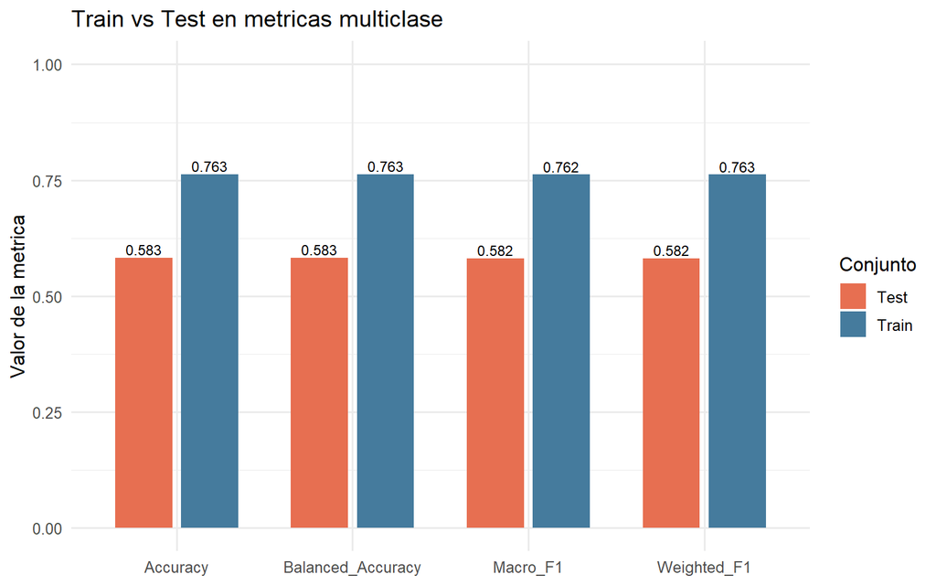

Comparacion de metricas de clasificacion entre train y test

```r
metricas_plot <- metricas_globales_train_test %>%
  select(Conjunto, Accuracy, Balanced_Accuracy, Macro_F1, Weighted_F1) %>%
  pivot_longer(
    cols = c(Accuracy, Balanced_Accuracy, Macro_F1, Weighted_F1),
    names_to = "Metrica",
    values_to = "Valor"
  )

ggplot(metricas_plot, aes(x = Metrica, y = Valor, fill = Conjunto)) +
  geom_col(position = position_dodge(width = 0.75), width = 0.65) +
  geom_text(
    aes(label = sprintf("%.3f", Valor)),
    position = position_dodge(width = 0.75),
    vjust = -0.25,
    size = 3.1
  ) +
  scale_fill_manual(values = c("Train" = "#457b9d", "Test" = "#e76f51")) +
  scale_y_continuous(limits = c(0, 1)) +
  labs(
    title = "Train vs Test en metricas multiclase",
    x = NULL,
    y = "Valor de la metrica"
  ) +
  theme_minimal(base_size = 12)
```

```r
# Validacion leave-one-out en train para reducir optimismo del train accuracy
pred_train_loo_cls <- knn.cv(
  train = X_train_norm,
  cl    = y_train_cls,
  k     = k_opt_cls
)

cm_train_loo_cls <- confusionMatrix(pred_train_loo_cls, y_train_cls)

accuracy_train_cls <- as.numeric(cm_train_cls$overall["Accuracy"])
accuracy_train_loo_cls <- as.numeric(cm_train_loo_cls$overall["Accuracy"])
accuracy_test_cls <- as.numeric(cm_test_cls$overall["Accuracy"])

comparacion_sobreajuste <- data.frame(
  Escenario = c("Train (autovecino)", "Train LOO (knn.cv)", "Test"),
  Accuracy = c(accuracy_train_cls, accuracy_train_loo_cls, accuracy_test_cls)
)

comparacion_sobreajuste %>%
  mutate(Accuracy = round(Accuracy, 4)) %>%
  kable(
    caption = "Evidencia de generalizacion y riesgo de sobreajuste",
    col.names = c("Escenario", "Accuracy")
  ) %>%
  kable_styling(bootstrap_options = c("striped", "hover"), full_width = FALSE)
```

Evidencia de generalizacion y riesgo de sobreajuste

| Escenario | Accuracy |
| --- | --- |
| Train (autovecino) | 0.7632 |
| Train LOO (knn.cv) | 0.5808 |
| Test | 0.5830 |

### Interpretacion tecnica para SmartStay Advisors

La matriz de confusion confirma que la mayor dificultad del modelo se concentra en la clase `media`, con un error significativamente mayor que en `barata` y `cara`. Las dos confusiones mas frecuentes son `media -> barata` y `media -> cara`, lo que sugiere que el modelo separa relativamente bien los extremos de precio, pero le cuesta ubicar con estabilidad las propiedades intermedias. En terminos operativos, esto es relevante porque las viviendas de segmento medio suelen actuar como frontera de decision comercial para ajustes de tarifa y priorizacion de inventario.

Desde la perspectiva de negocio, no todos los errores tienen el mismo costo. Confundir una vivienda `cara` con `media` puede inducir ajustes de precio moderados y decisiones menos agresivas, mientras que confundir `cara` con `barata` puede llevar a subvaloraciones severas y perdida de ingreso potencial por noche. De manera simetrica, predecir una vivienda `barata` como `cara` puede sobredimensionar su posicionamiento y afectar conversion al fijar precios por encima de la disposicion real del mercado.

Sobre sobreajuste, la comparacion directa de train vs test con autovecino muestra una brecha amplia (train mayor que test), esperable en KNN cuando se evalua entrenamiento sobre los mismos datos usados como vecinos y con un `k` pequeno (k = 3). Sin embargo, al usar `knn.cv` (LOO) el accuracy de train se alinea casi por completo con test, lo cual reduce la evidencia de sobreajuste severo y apunta mas bien a un problema de estimacion optimista en la metrica de entrenamiento inicial. En resumen, `k = 3` hace al modelo sensible a variacion local; funciona, pero conviene validar con esquemas de CV mas robustos y explorar valores de `k` ligeramente mayores para mejorar estabilidad en la clase media.

### Texto formal para reporte

El desempeno del clasificador KNN evidencia una capacidad predictiva moderada sobre el conjunto de prueba, con una exactitud global de 0.583 y un F1 macro de 0.582. El analisis de la matriz de confusion muestra que los errores se concentran principalmente en el segmento de precio medio, mientras que las categorias extrema inferior y superior presentan mayor estabilidad relativa. Este patron sugiere que el modelo distingue adecuadamente viviendas baratas y caras, pero encuentra ambiguedad en observaciones cercanas a los umbrales intermedios. Desde la perspectiva de SmartStay Advisors, la severidad del error depende del salto entre segmentos: clasificar propiedades caras como medias implica un desajuste de valor menos critico que clasificarlas como baratas, escenario que puede traducirse en decisiones de pricing con impacto directo en ingresos. Aunque la comparacion inicial entre entrenamiento y prueba sugiere una brecha importante, la validacion leave-one-out en entrenamiento produce resultados practicamente equivalentes a los de prueba, por lo que la evidencia apunta mas a optimismo de la metrica in-sample que a un sobreajuste estructural del modelo. En este contexto, el valor de `k` seleccionado prioriza flexibilidad local, pero se recomienda continuar con validacion cruzada y ajuste fino para mejorar la robustez de clasificacion, especialmente en la clase media.

```r
save(
  train_cls, test_cls,
  q33_c, q67_c,
  y_train_cls, y_test_cls,
  k_opt_cls, pred_test_cls,
  cm, accuracy_cls, metricas_resumen, errores_por_clase,
  pred_train_cls, pred_train_loo_cls,
  cm_train_cls, cm_test_cls, cm_train_loo_cls,
  metricas_clase_train, metricas_clase_test, metricas_globales_train_test,
  pares_confusion, errores_por_clase_test, comparacion_sobreajuste,
  accuracy_train_cls, accuracy_train_loo_cls, accuracy_test_cls,
  file = "knn_clasificacion_resultados.RData"
)

cat("Objetos exportados a: knn_clasificacion_resultados.RData\n")
```

```
## Objetos exportados a: knn_clasificacion_resultados.RData
```

## integración

```r
cat("- Unificar nombres de objetos entre secciones: train_raw, test_raw, X_train_norm, X_test_norm.\n")
```

- Unificar nombres de objetos entre secciones: train_raw, test_raw, X_train_norm, X_test_norm.

```r
cat("- Mantener formato de tablas con kable + kableExtra.\n")
```

- Mantener formato de tablas con kable + kableExtra.

```r
cat("- Usar misma paleta visual en gráficos comparativos.\n")
```

- Usar misma paleta visual en gráficos comparativos.

```r
cat("- Consolidar conclusiones en tono consultoría (hallazgo -> implicación -> recomendación).\n")
```

- Consolidar conclusiones en tono consultoría (hallazgo -> implicación -> recomendación).

```r
cat("- Evitar subtítulos que copien literalmente los enunciados del laboratorio.\n")
```

- Evitar subtítulos que copien literalmente los enunciados del laboratorio.